```python
import warnings
import datetime

import numpy as np
import matplotlib.pyplot as plt
import pandas as pd
import seaborn as sns

from sklearn.model_selection import train_test_split
from IPython.display import display, Markdown , Math

sns.set()
warnings.filterwarnings('ignore')
```

```python
def printmd(string): display(Markdown(string))
def latex(out): printmd(f'{out}')
def pr(string): printmd('***{}***'.format(string))
```

# Softmax Regression </h2>

## author: daodeiv (David Stankov)

[figure not shown]

###### Abstract Softmaxt definition and how it works? Optimizaton of Softmax Loss with Gradient Descent (Deep math calculation) Implementation of Softmax using numpy Regularization of softmax by learning rate and max iterations Conclusion

The Softmax function maybe is one of the most popular Machine learning algorithm basically, it turns arbitrary real values into probabilities, by using the exponential function. It could be considered as generalization of the sigmoid function. We could use softmax for multi-class classification furthermore it is met in many various fields of science as Statistical physics (Gibbs distributions), Quantum statistic, Information theory, and Neural networks. Softmax is much attractive in classification problems since it has a simple implementation and in many cases gives satisfying results and enough good performance.

We gonna use the Iris dataset because it is comparatively simple and very convenient in the studying of Machine Learning.

```python
iris = pd.read_csv("../../../resources/data/IRIS.csv")
iris.head()
```

|  | sepal_length | sepal_width | petal_length | petal_width | species |
| --- | --- | --- | --- | --- | --- |
| 0 | 5.1 | 3.5 | 1.4 | 0.2 | Iris-setosa |
| 1 | 4.9 | 3.0 | 1.4 | 0.2 | Iris-setosa |
| 2 | 4.7 | 3.2 | 1.3 | 0.2 | Iris-setosa |
| 3 | 4.6 | 3.1 | 1.5 | 0.2 | Iris-setosa |
| 4 | 5.0 | 3.6 | 1.4 | 0.2 | Iris-setosa |

```python
pr('labels value : ' +str(iris['species'].unique()))
```

*labels value : ['Iris-setosa' 'Iris-versicolor' 'Iris-virginica']*

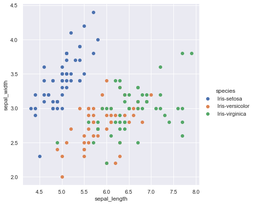

```python
sns.FacetGrid(iris,hue='species',height=6).map(plt.scatter,'sepal_length','sepal_width').add_legend()
```

We are going to express the label values as one-hot encoding variables or so-called dummies variables.

```python
x_train = iris.drop('species', axis=1)
y_train = pd.get_dummies(iris['species'])
pr('One hode encoding representation')
y_train.head()
```

*One hode encoding representation*

|  | Iris-setosa | Iris-versicolor | Iris-virginica |
| --- | --- | --- | --- |
| 0 | 1 | 0 | 0 |
| 1 | 1 | 0 | 0 |
| 2 | 1 | 0 | 0 |
| 3 | 1 | 0 | 0 |
| 4 | 1 | 0 | 0 |

```python
x_train, y_train = np.array(x_train), np.array(y_train)
pr('shape X :'+ str(x_train.shape))
pr('shape X :'+ str(y_train.shape))
```

*shape X :(150, 4)*

*shape X :(150, 3)*

```python
X_train, X_test, y_train, y_test = train_test_split(x_train,y_train, test_size=0.33, random_state=42) #separats into test and train samples
```

## Softmaxt definition and how it works?

The softmax function $\sigma: \; \Re^k \; \rightarrow \; \Re^k $ could be defined by formula :

$$ (1) \;\; \sigma_{softmax}({z^i})_{ij} =\frac {e^{z_{ij}} }{ \sum_i^k e^{z_{ik}} } $$

$\; \; z_{ij} = \sum_p x_{ip} w_{jp} + b_j $  
$\; \; \vec{z_i} = z^i= [z_{i1}, z_{i2}, ...z_{ik} ] $

$$\sigma_{softmax (W,b,X^{i})_{ij}}=\frac{e^{ \sum_p x_{ip} w_{pj} + b_j}}{\sum_j^k e^{ \sum_p x_{ip} w_{pj} + b_j}} $$

###### Index convetions. When we note for example $Q_{lh}$ or $q_{ih}$ we will mean the element of matrix $Q_{M\times N}$ where $l$ refers to row $h$ to column. When we write $Q^{i}$ or $q_{i}$ we will assume that as vector row $\vec Q^{i}= [q_{i1},q_{i2},...q_{in}]\in Q_{m\times n}$. In eq(1) $z^i=[z_{i1}, z_{i2}, ...z_{in}] $

The softmax function takes as an input a vector $z^i$ with $K$ number of component $z_{i1}, z_{i2}, ...,z_{in}$ and normalized it into a probability distribution $p^{i}$ consisting of also $K$ number of probabilities $p_{i1},...,p_{ik}$ proportional to exponentials of input values $z^{i}$. That is, prior to applying softmax function some vector components of $z^{i}$ could be negative or greater than 1 and might not sum up to 1. Furthermore more the larger input components correspond to larger probabilities and $\sum_j p_{ij}=1$. The $w_{jp}$ are the wights or estimators $w_{pj}\in W^{K\times N}$ In matrix $W^{K\times N}$ $K$ coresponds to number of class labels and $N$ coresponds to number of atrribute(feature) of training data, and $ b = [b_1, ...b_k]$ is slopes term with component coresponds to class labels.

This property of softmax function that it outputs a probability distribution makes it suitable for probabilistic interpretation in classification tasks.

According to our dataset, we can write the folowing expressions.

$W= \begin{bmatrix} weight^1\rightarrow class \; 1(Iris-setosa) \\ weight^2\rightarrow class\; 2(Iris-versicolor) \; \\ weight^{3}\rightarrow class \;3(Iris-virginica) \; \end{bmatrix} = \begin{bmatrix} \vec W^1 \\ \vec W^2\ \\ \vec W^3 \end{bmatrix} = \begin{bmatrix} w_{11} & w_{12} & w_{13} & w_{14} \\ w_{21} & w_{22} & w_{23} & w_{24} \\ w_{31} & w_{32} & w_{33} & w_{34} \end{bmatrix} $  
$ B= \begin{bmatrix} b_1 \\ b_2\ \\ b_3 \end{bmatrix}\;\;\;$

vector $\vec W^i=[w_{i1},..w_{in}]$ is estimator vector for taget class (label) $i$ , $n$ coresponds to the feature (pridictor) of $X$

in matrix form the $Z$ is expressed as : $Z = XW^T$  
$Z = \begin{bmatrix} x_{11} & x_{12} & x_{13} & x_{14} \\ x_{21} & x_{22} & x_{23} & x_{24}\\ ... & ... & ... & ...\\ x_{m1} & x_{m2} & x_{m3} & x_{m4} \end{bmatrix} \times \begin{bmatrix} w_{11} & w_{21} & w_{31} \\ w_{12} & w_{22} & w_{32} \\ w_{13} & w_{23} & w_{33} \\ w_{14} & w_{24} & w_{34} \end{bmatrix} + \begin{bmatrix} b_1 \\ b_2\ \\ b_3 \end{bmatrix} = \begin{bmatrix} z_{11} & z_{12} & z_{13} \\ z_{21} & z_{32} & z_{33} \\ ... & ... & ... \\ z_{m1} & z_{m2} & z_{m3} \end{bmatrix} $

The softmax function computes the probability that a training example $X^{(i)}$ belongs to class $y^{j}$ given the weight matrix $W$ and bias (slope) $\vec b$ .  
So we compute the probability :

$$p_{ij}=P(y_{j} \;| \;z^i) = \sigma_{softmax (z)_{ij}}=\frac{e^{z_{ij}}}{\sum_p^K e^{z_{ip}}} $$

for all $P_{ij}$ and given target components $Y = [y^1 -Iris-setosa,y^2 -Iris-versicolor,y^3- Iris-virginica]$ we can write :

$$ P = \begin{bmatrix} p(y_{1} |z^{1})_{11} & p(y_{2} |z_{2} )_{12} & p(y^{3} |z^{3} )_{13} \\ ... & ... & ... \\ P(y_{1} |z^{m} )_{m1} & P(y_{m} |z^{m} )_{m2} & P(y_{3} |z^{m} )_{m3} \end{bmatrix} = \begin{bmatrix} \frac{e^{z_{11}}}{\sum_{1j}e^{z_{1j}}} & \frac{e^{z_{12}}}{\sum_{1j}e^{z_{1j}}} & \frac{e^{z_{13}}}{\sum_{1j}e^{z_{1j}}} \\ \\ ... & ... & ... \\ \\ \frac{e^{k_{n1}}}{\sum_{j}^3e^{z_{nj}}} & \frac{e^{z_{n2}}}{\sum_{j}^3e^{z_{nj}}} & \frac{e^{z_{n3}}}{\sum_{j}^3e^{z_{nj}}}\end{bmatrix} $$

for example, the probability of record $x^1$ to belongs to target label $y_2$ (Iris-versicolor) is calculated as:

$$p_{12} =P(y=2 |x^{1}) = \frac{ e^{ ^{z_{12}} } }{ \sum_p^3 e^{z_{1p}}}=\frac{ e^{ (^{\sum_v^3 x_{1v}.w_{vj} + b_v }} )}{ \sum_k^3 e^{ ^ ({\sum_v^3 x_{1v}.w_{vk}} + b_k})}$$

always the $p_{ij} \in [0,1]$ and $\sum_j p_{ij}= 1$

Let's see how the softmax function can be applied concretely in our training dataset. First, let to define a weight matrix $W$ and bias $\vec b$  
$W =\begin{bmatrix} w_{11} & w_{12} & w_{13} & w_{14} \\ w_{21} & w_{22} & w_{23} & w_{24} \\ w_{31} & w_{32} & w_{33} & w_{34} \end{bmatrix} = \begin{bmatrix} 1.38618464 & 1.9151765 & -0.28863154 & 0.40849489 \\1.31642223 & 0.76753677 & 1.1482473 & 0.74274245 \\0.29739313 & 0.31728673 & 2.14038423 & 1.84876265\end{bmatrix}$  
$B = \begin{bmatrix} 1.18749764 \\ 1.16215506 \\0.6503473 \end{bmatrix} $

I've prepared weight vector $W$ and bias $B$ in advance, how? We will see later.

```python
W = np.array([[ 1.38618464,  1.9151765 , -0.28863154,  0.40849489],
        [ 1.31642223,  0.76753677,  1.1482473 ,  0.74274245],
        [ 0.29739313,  0.31728673,  2.14038423,  1.84876265]]) # define a weight matrix

b = np.array([1.18749764, 1.16215506, 0.6503473 ])  #bias vector (intercept)
```

The implementation of softmax function:

```python
def softmax(X, weight, b):
    '''
    perform softmax function

    Parameters :
    X : ndarray
       train data
    weight : ndarray
       weght matrix
    b : ndarray
        bias vector

    Returns
       ndarray
    '''

    #dot product between X_data matrix  and tranposed Weight_ matrix added to Bias  gives matrix each z_ij
    Z = X.dot(weight.T)

    #return matrix cosist of exponentials Z input net
    exp_z = np.exp(Z)

    #array contains sum  of every row  (e^z_{ik})
    sums=np.sum(exp_z, axis=1)

    #return softmax(Z)_{ij}
    return (exp_z.T/sums).T


def accuracy(Y, P):
    '''
    evualate accuracy of dummies variable

    Parameters :
    Y_target : ndarray
      actual real values
    P : ndarray
     predicted values (probability)
    Return
      float
    '''

    C =  np.argmax(Y, axis=1)==np.argmax(P, axis=1)
    D = np.where(C==True)
    return len(D[0])/len(C)
```

```python
pr( "original data label " +r'$ Y_{{M\times N}} :$'.format(X_test.shape))
actual_label = pd.DataFrame(y_train,columns = ['Iris-setosa', 'Iris-versicolor','Iris-virginica'])
actual_label.head()
```

*original data label $ Y_{M\times N} :$*

|  | Iris-setosa | Iris-versicolor | Iris-virginica |
| --- | --- | --- | --- |
| 0 | 0 | 1 | 0 |
| 1 | 0 | 0 | 1 |
| 2 | 0 | 1 | 0 |
| 3 | 1 | 0 | 0 |
| 4 | 0 | 0 | 1 |

```python
pr("predicted data label " +r'$ P_{{M\times N}} :$'.format(X_test.shape))
predict = softmax(X_train,W,b)
predict = pd.DataFrame(predict,columns = ['Iris-setosa', 'Iris-versicolor','Iris-virginica'])
predict.head()
```

*predicted data label $ P_{M\times N} :$*

|  | Iris-setosa | Iris-versicolor | Iris-virginica |
| --- | --- | --- | --- |
| 0 | 0.050053 | 0.777979 | 0.171968 |
| 1 | 0.001113 | 0.555302 | 0.443584 |
| 2 | 0.030317 | 0.696057 | 0.273627 |
| 3 | 0.907907 | 0.091569 | 0.000524 |
| 4 | 0.000807 | 0.561198 | 0.437995 |

```python
a =accuracy(np.array(y_train),np.array(predict))
pr('accuracy : '+str(a))
```

*accuracy : 0.75*

## Optimizaton of Softmax Loss with Gradient Descent (Deep math calculation)

For objective loss function we will use Cross-Entropy wich is used binary logistic reg.Sofmax Loss is defined as :

$$ (2)\;\; \mathcal{L}(Y,Z)=-\sum_i^m\sum_j^k y_{ij} \log (p(Z)_{ij})$$

Where $m$ is a count of records , $k$ is count of classes $y_{ij}$ is label values , $p_{ij}=\phi_{softmax}(Z)_{ij}$ are Y' predicited class values and $Z$ is net input which is function of $W$ is weight matrix and $b$ bias and $X$

Our goal is to minimize the eq.(2) in order to find the best estimators $w_{ij}\in W$ and $b$ given the iris data $X$ and a label data $Y$.  
We are going to use Gradient descent for optimization process. Note that, the eq.(2) is the function of all weights $w_{ij}$, bias $b_j$ all training data X and label data Y.

Gradient descent is defined as :
$$ \; \; \; \; \; \; \;\begin{matrix} w_{ij} = w_{ij} - \lambda \nabla w_{ij}L(W,b,X,Y) \\ \\ b_{j} = b_j - \lambda\nabla b_{j}L(W,b,X,Y) \end{matrix} $$ where $\lambda$ is learning rate or step size

Plug eq.(2) in gradient descent we achieve the general formula :
$$(3) \; \; \; \; \; \; \begin{matrix} \nabla w_{ij}L(Y,P) &= \nabla w_{ij}L(Y,P) -\frac{\partial}{\partial w_{ij}}\Big(\sum_k^m\sum_n^n y_{mn} \log {p_{mn}}\Big) \\ \\ \nabla b_{j}L(Y,P) & = \nabla b_{j}L(Y,P) - \frac{\partial}{\partial b_{j}}\Big(\sum_k^m\sum_n^n y_{mn} \log{p_{mn}}\Big) \end{matrix} $$

Before we take up with $\nabla w_{ij}L(W,b)$. We gonna introduce some math technics which will make our work easier.
For simplicity in the summation process of indices, we will introduce a [Kronecker symbol](http://physics.csusb.edu/~prenteln/notes/vc_notes.pdf) .
</font> $$\delta_{ij} = \begin{equation} \begin{Bmatrix} 1 & if \; i=j \\ 0 & if \; i\ne j \end{Bmatrix} \end{equation}$$
$$ \delta_{ij} = \begin{bmatrix} 1 & 0 & 0 \\ 0 & 1 & 0 \\ 0 & 0 & 1 \end{bmatrix}$$ In many places in the coming sum operations over indexes we will miss the $\sum$ symbol, just it will be avoided(hidden) according to the .[Einstein summation convention](https://en.wikipedia.org/wiki/Einstein_notation) .
For example, the equation.

$$z_{ij} = \sum_p^3 x_{ip} w_{jp} + b_j $$ by applying the Enstein convetion we could rewrite it as :

$$z_{ij} = x_{ip} w_{jp} + b_j$$
The sign $\sum_p^3$ is miss.The sumation over p is implied(by default) because p is repeated twice.Every time when there are repeatable indices that is the indicator for exist of $\sum$ which is just missing(The sum sign is not written).

In order to minimize the entropy of data, we must to take up with minimizatin of Cross entropy loss respect to $w_{ij}$.The cross-etropy Loss is a function of all feature vectors $X_{M\times N}$ ,all labels $X_{M\times K}$ , weight $W_{K\times N}$ and bias $B_K$  
$L = L(X,T,W,B)$

$\frac{\partial L}{\partial w_{ij}}=-\frac{\partial}{\partial w_{ij}}\Big(\sum_k\sum_n y_{mn} \log {p_{mn}}\Big)$ $=\sum_k\sum_n y_{mn}\frac{\partial \log {p_{mn}}}{\partial w_{ij}}$

$=-\sum_m\sum_n\frac{y_{mn}}{p_{mn}}\frac{\partial p_{mn}}{\partial w_{ij}} $ $=\sum_m\sum_n \frac{y_{mn}}{p_{mn}}\frac{\partial p_{mn}}{\partial z_{vp}}\frac{\partial z_{vp}}{\partial w_{ij}} $

###### from $z_{vp} = f(w_{pi}) \Rightarrow \frac{\partial z_{vp}}{\partial w_{ij}} = 0\;$ if $\; p\ne i$ then we can write $ \frac{\partial z_{vp}}{\partial w_{ij}}=\delta_{pi}\frac{\partial z_{vp}}{\partial w_{ij}}$ and $p_{mn} = f(z_{mv}) \Rightarrow \frac{\partial z_{vp}}{\partial w_{ij}} = 0$ if $ m\ne v $ then $\frac{\partial p_{mn}}{\partial z_{vp}}=\delta_{mv}\frac{\partial p_{mn}}{\partial z_{vp}} $ plug in it we will achieve

$ =-\sum_m\sum_n \frac{y_{mn}}{p_{mn}}\delta_{mv}\frac{\partial p_{mn}}{\partial z_{vp}} \delta_{pi}\frac{\partial z_{vp}}{\partial w_{ij}} $

###### using common Kronicker $\delta$ proprties

$=-\sum_m\sum_n \frac{y_{mn}}{p_{mn}}\delta_{mm}\delta_{ii}\frac{\partial p_{mn}}{\partial z_{mi}}\frac{\partial z_{mi}}{\partial w_{ij}} $ $=-\sum_m\sum_n \frac{y_{mn}}{p_{mn}}\frac{\partial p_{mn}}{\partial z_{mi}}\frac{\partial z_{mi}}{\partial w_{ij}} $

We've successfully reduced the count of sum operations, using Einstein's convention and Kronecker symbol and achieved

$\frac{\partial L}{\partial w_{ij}}=-\sum_m\sum_n \frac{y_{mn}}{p_{mn}}\frac{\partial p_{mn}}{\partial z_{mi}}\frac{\partial z_{mi}}{\partial w_{ij}}$

Let to focus on terms $\frac{\partial p_{mn}}{\partial z_{mi}}$ and $\frac{\partial z_{mi}}{\partial w_{ij}}$

$\frac{\partial p_{mn}} {\partial z_{mi}}=\frac{\partial\frac { e^{z_{mn}} }{ \sum_ke^{z_{mk}}} }{\partial z_{mi}}$ $=\frac{1}{(\sum_ke^{z_{mk}})^2}\times \Big(\frac{\partial e^{z_{mn}} }{\partial z_{mi}}\times(\sum_ke^{z_{mk}}) - e^{z_{mn}}\times\frac{\partial (\sum_ke^{z_{mk}})}{\partial z_{mi}} \Big)$

$=\frac{e^{z_{mn}}\times\frac{\partial z_{mn}}{\partial z_{mi}}}{\sum_ke^{z_{mk}}} - \frac{e^{z_{mn}}}{\sum_ke^{z_{mk}}}\times\frac{ \sum_k e^{z_{mk}} \frac{ \partial z_{mk}}{\partial z_{mi}}} {\sum_ke^{z_{mk}}}$

###### from $\frac{\partial z_{mk}}{\partial z_{mi}}=0$ if $k\ne i\;\frac{\partial z_{mk}}{\partial z_{mi}}=1\;ifk = i\;\Rightarrow \frac{\partial z_{mk}}{\partial z_{mi}}=\delta_{ki} $ plug in

$=\frac{e^{z_{mn}}\times \delta_{ni} }{\sum_ke^{z_{mk}}} - \frac{e^{z_{mn}}}{\sum_ke^{z_{mk}}}\times\frac{ \sum_k e^{z_{mk}}\delta_{ki}} {\sum_ke^{z_{mk}}}$ $=\frac{e^{z_{mn}}\times \delta_{ni} }{\sum_k e^{z_{mk}}} - \frac{e^{z_{mn}}}{\sum_ke^{z_{mk}}}\times\frac{ \sum_k e^{z_{mk}}\delta_{ki}} {\sum_ke^{z_{mk}}}$

$=\frac{e^{z_{mn}}\times \delta_{ni} }{\sum_ke^{z_{mk}}} - \frac{e^{z_{mn}}}{\sum_ke^{z_{mk}}}\times\frac{ \sum_k e^{z_{mi}}\delta_{ii}} {\sum_ke^{z_{mk}}}$ $=\frac{e^{z_{mn}}\times \delta_{ni} }{\sum_ke^{z_{mk}}} - \frac{e^{z_{mn}}}{\sum_ke^{z_{mk}}}\times \frac{ e^{z_{mi}}}{\sum_ke^{z_{mk}}}$

###### from eq.(1) $\Rightarrow$ $\frac{ e^{z_{mn}} }{ \sum_k e^{z_{mk} } }=p_{mn}$ and $\frac{ e^{z_{mi}} }{ \sum_k e^{z_{mk} } }=p_{mi}$ when we apply it, we will achieve

$=p_{mn}\times \delta_{ni} - p_{mn}\times p_{mn}p_{mi}$  
$=p_{mn}(\delta_{ni} - p_{mi})$

For term $\frac{\partial p_{mn}} {\partial z_{mi}}$ we achieve :
$$4) \; \; \; \; \frac{\partial p_{mn}} {\partial z_{mi}}=p_{mn}(\delta_{ni} - p_{mi})$$

$\frac{\partial z_{mi}}{\partial w_{ij}} =\frac{\partial ( \sum_k x_{mk}w_{ki})}{\partial w_{ij}}= \frac{ \sum_k z_{mi} x_{mk}\partial w_{ki}}{\partial w_{ij}}$

###### $\frac{\partial w_{ki}}{\partial w_{ij}} = \delta_{kj}$ only a direct verification can proof it

$= \sum_k x_{mk} \delta_{kj} =\sum_k x_{mj}\delta_{jj}=x_{mj}$

###### and for $\frac{\partial z_{mi}}{\partial w_{ij}}$ we achive :

$$(5) \;\;\;\;\;\frac{\partial z_{mi}}{\partial w_{ij}} = x_{mj} $$

###### Applying eqs.(4) (5) in : $\frac{\partial L}{\partial w_{ij}}=-\sum_m\sum_n \frac{y_{mn}}{p_{mn}}\frac{\partial p_{mn}}{\partial z_{mi}}\frac{\partial z_{mi}}{\partial w_{ij}}$ we have :

$\frac{\partial L}{\partial w_{ij}}=-\sum_m\sum_n \frac{y_{mn}}{p_{mn}}p_{mn}(\delta_{ni} - p_{mi})x_{mj}=--\sum_m\sum_n y_{mn}(\delta_{ni} - p_{mi})x_{mj} $

$ =-\sum_m\sum_n y_{mn}\delta_{ni} + \sum_m\sum_n y_{mn} p_{mi}x_{mj} $

###### we can replace an index $n$ with $i$ (!There is no $\sum_i$)

$ =-\sum_m\sum_n y_{mi}\delta_{ii}x_{mj} + \sum_m\sum_n y_{mn} p_{mi}x_{mj} $

$ =-\sum_m y_{mi}x_{mj} + \sum_m\sum_n y_{mn} p_{mi}x_{mj} $  
$\sum_n y_{in}=1$

###### (the sum of all probability) applying it

$ =-\sum_m y_{mi}x_{mj} + \sum_m 1. p_{mi}x_{mj} = \sum_m p_{mi}x_{mj}-\sum_m y_{mi}x_{mj}$  
$ = \sum_k^m( p_{mi}-y_{mi})x_{mj}$

We've achieved the most important result .The optimization of Cross-entropy respect to $w_{ij}$ :

$$6) \;\;\;\;\nabla w_{ij}L(W,b)= \sum_m( p_{mi}-y_{mi})x_{mj}$$

If we apply the same step for $\nabla b_{i}L(W,b)$ (It is an easier one) we will achieve the minimization formula for bias , which looks like this
$$7)\;\;\;\;\nabla b_{i}L(W,b)= \sum_m( p_{mi}-y_{mi})$$

Although the eq.(6) seems so simple and elegant it is written in a tensor form, not in matrix one. Therefore its implementation becomes more difficult, especially when we want to use our lovely library NumPy.But we can write the equation in matrix form seeming like that :

$\nabla_W L = \begin{bmatrix} \nabla_{w_{11}} L & \nabla_{w_{12}}L &... &\nabla_{ w_{1j}}L \\ \nabla_{ w_{21}}L & \nabla_{ w_{22}}L &... &\nabla_{ w_{2j}}L \\ ... & ... & ... & ... \\ \nabla_{ w_{i1}}L & \nabla_{ w_{i2}}L & ...& \nabla_{ w_{ij}}L \end{bmatrix} $ $ =\begin{bmatrix} p_{11} -y_{11} & p_{21}-y_{21} & ... & p_{m1}-y_{m1}\\ p_{12} -y_{12} & p_{22}-y_{22} & ... & p_{m2}-y_{m2}\\ \;\;...\;\;\; & \;\;...\;\;\; &\;\;...\;\;\; &\;\;...\;\;\; \\ p_{1i} -y_{1i} & p_{2i}-y_{2i} & ... & p_{mi}-y_{mi} \end{bmatrix}$ $\begin{bmatrix} x_{11} & x_{12} &...& x_{1j} \\ x_{21} & x_{22} &...& x_{2j} \\ ... & ... & ... &... \\ x_{m1} & x_{m2} &...& x_{mj}\end{bmatrix}$

$$8)\;\;\;\;\nabla_W L = (P-Y)^T.X$$

$$\;\;\;\;\nabla_{b_i} L = \sum_m (P-Y)_{mi}\;\;\; or $$ or
$$9)\;\;\;\;\nabla_{b} L =\Big[\sum_m (P-Y)_{m1}, \sum_m (P-Y)_{m2},..., \sum_m (P-Y)_{mi}\Big]$$

We've written eq(6) and(7) in matrix form, and result is surprisingly simple and so easy for implementation.If we plug the eq(8) and (9) in gradient descent eqaution
$$ \; \; \; \; \; \; \;\begin{matrix} w_{ij} = w_{ij} - \lambda \nabla w_{ij}L(W,b) \\ \\ b_{j} = b_j - \lambda\nabla b_{j}L(W,b) \end{matrix} $$

We've achieve our minimization alogithm for Cross-entopy Loss for find the best esitmitators $W_{ij}$. The minimization alogorithm using gradient descent is deifined as :

$$(10) \; \; \; \; \; \; \; W= W -\lambda(P-Y)^T.X $$
$$(11) \; \; \; \; \; \; \; b_i = b_i -\lambda \sum_m(P-Y)_{mi} $$

where W is a weight matrix , $\lambda$ is an leraning rate or step size, P is the the prediction values pruduced from sofmax $Y$ is the target values $X$ is the training data (features vectors).

## Implementation of Softmax using numpy

The implentation using numpy could be defined as :  
:

$$ W = W - gamma*(( softmax(W,b,X,Y) -Y )^T).dot(X)$$
$$ b_i = b_i - gamma*sum_m((softmax(W,b,X,Y)_i -Y_i)) $$

where the arguments are considered: the W matrix our estimator coeficients , $gamma=$ $\lambda* (1/m)$ step size, $\lambda$ learning rate $Y$ is the target values $X$ is the training data (features vectors). The implementation of gradient descent

```python
def gradient_descent(X, y, W, b, step_size):
    ''''
    one iteration(Epoch) perform  gradient descent

     Parameters :
    X : ndarray
       train data
    y : ndarray
       target data
    W : ndarray
     weight matrix
    b : ndarray
      bias
    step_size : float
       gradient descent setting

    '''
    P_y = softmax(X,W,b)-y
    W = W - step_size*(P_y.T).dot(X)
    b = b - step_size*np.sum(P_y, axis=0)
    return W,b


def train(X , y, max_iter=100,learning_rate=0.1,innitial_value =1, debug_W=None):
    '''
    Train by softmax regression

    Parameters :
    X : ndarray
       train data
    y : ndarray
       target data
    max_iter : int
        number of epoch (iterations)

    debug_W : tuple
       index of weight parameter for debugging
    Returns
       W, b : ndarray
         weight and bias
       in debug mode
       W, b, k : ndarray
          weight and bias and debugind parameter


    '''

    if type(X) != np.ndarray or type(y) != np.ndarray:
        raise ValueError('X and y must be ndarray')

    #init weight and bias
    b = np.full((y.shape[1],),innitial_value)
    W = np.full((y.shape[1], X.shape[1]), innitial_value)

    m = X.shape[0]
    step_size = (1/m)*learning_rate

    if debug_W is not None:
        debug_mode=True
        debug = W[(debug_W)]
    else :
        debug_mode=False

    for i in range(max_iter):
        W,b = gradient_descent(X , y, W, b,step_size)
        if debug_mode: debug = np.append(debug, W[debug_W])


    if debug_mode: return W,b,debug

    return W,b
```

Let to test our implementation and to train the iris data  
Trainig data

```python
W,b = train(np.array(X_train), np.array(y_train),max_iter=100)
```

```python
print('weight vector :'+ str(W))
print('')
print('bias :'+ str(b))
```

```
weight vector :[[ 1.35411091  1.84190926 -0.19105989  0.45297526]
 [ 1.27780858  0.77747064  1.17029213  0.79586893]
 [ 0.36808051  0.3806201   2.02076776  1.75115581]]

bias :[1.17282574 1.13488628 0.69228799]
```

```python
predict = softmax(np.array(X_test), W,b)
#print(v)
pr('accuracy:  ' +str(accuracy(np.array(y_test), predict))+'%')
```

*accuracy: 0.7%*

We've achieved 70% acuracy , learning rata = 0,1 max iteration 100

Testing on data X_test and y_test

## Regularization of softmax by learning rate and max iterations

We will try to see the behavior of Gradient respect to different learning rates and max iterations.

Debugging tool implemetation

```python
def debug_gradient(max_iter, l_rates=(100, 50, 10, 5, 1, 0.1), call_function = train, debug_weight=(1,1), y_size = [-20,20]):
    '''
    Parameters
    max_iter : number
        maxumim count of itertation (epoch)
    l_rates : typle
        different learning rates
    deebug_weight : type
       index of weight parameter wich will be debug

    '''
    i=-1
    plt.figure(figsize=(15,5))
    axes =plt.gca()
    axes.set_ylim(y_size)
    axes.set_xlabel(r' $log(number\; of\; iteration)$'.format(max_iter))
    axes.set_ylabel(r'weight parameter: $W_{}$'.format(debug_weight))
    for learning_rate in l_rates:
        i+=1
        start = datetime.datetime.now()
        W,b,w_11 = train(X_test,y_test,max_iter=max_iter,learning_rate=learning_rate,debug_W=debug_weight)
        accr = accuracy(y_test, softmax(X_test,W,b))*100
        time = int((datetime.datetime.now()-start).total_seconds()*1000 )
        x = np.linspace(1, len(w_11) , len(w_11))
        plt.plot(np.log(x),w_11,label=r'$\lambda$ = {} , accr:{} %'.format(learning_rate, accr),color=cmap[i])
        plt.title("Curve of weight estimator $W${} ,{} iterations, time for excution {}ms".format(debug_weight, max_iter, time))
        plt.legend()
    plt.show()

cmap = ['#701b1b','#a7ba1a','#1aba25','#1a75ba','#9a1aba','#7d1aba','#ba1a45']
```

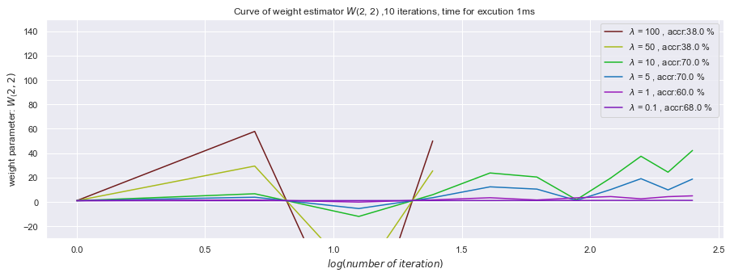

```python
debug_gradient(10, debug_weight=(2, 2), y_size=[-30,150])
```

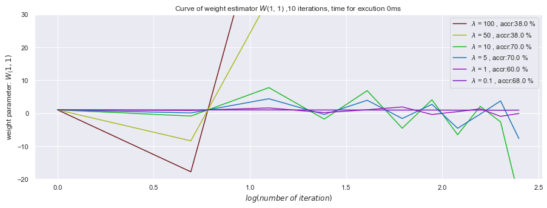

```python
debug_gradient(10,y_size=[-20,30])
```

In above both graphic we see the evolution of weight components $w_{22}$ and $w_{11}$ respect to log(epoch) or len of iteration. From graphics, we may could conclude that all values are an arbitrary wrong moreover the larger $\lambda$ corresponds to larger fluctuations leading to a larger interval in which the values can vary, the reason for that is a small iterations.

Incresing of max iteration to 150

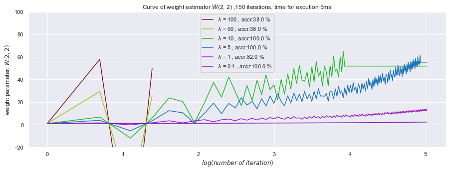

```python
debug_gradient(150, debug_weight=(2, 2), y_size=[-20,100])
```

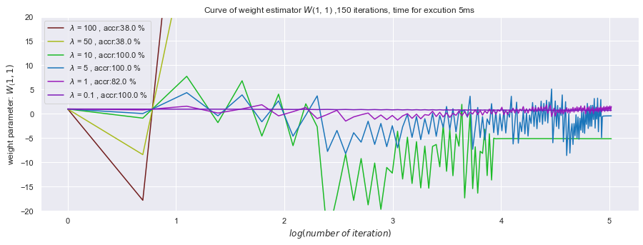

```python
debug_gradient(150)
```

In fact, we are not able to judge which are the best $\lambda $ and $M$, since the dataset is small although we could assume that the smaller $\lambda $ and the bigger $M$ often leads to good results at the expense of execution time and a big risk to achieve overfitting. In summary, every dataset has a unique set of $\lambda$, $M$ wich will give satisfying accuracy and in order to achieve the best ones we have to take up with the experiments over them.

## Conclusion

We have walked step by step from math to implementation of multi-class classification using softmax regression. That could be used as a guide for implementation of logistic regression and some notes related to optimization could be useful for neural networks